# GDCRNATools: integrative analysis of protein coding genes, long non-coding genes, and microRNAs in GDC

Ruidong Li and Han Qu

Last update: 24 January, 2018

# 1 Introduction

`GDCRNATools` is an R package which provides a standard, easy-to-use and comprehensive pipeline for downloading, organizing, and integrative analyzing RNA expression data in the GDC portal with an emphasis on deciphering the lncRNA-mRNA related ceRNAs regulatory network in cancer.

Competing endogenous RNAs (ceRNAs) are RNAs that indirectly regulate other transcripts by competing for shared miRNAs. Although only a fraction of long non-coding RNAs has been functionally characterized, increasing evidences show that lncRNAs harboring multiple miRNA response elements (MREs) can act as ceRNAs to sequester miRNA activity and thus reduce the inhibition of miRNA on its targets. Deregulation of ceRNAs network may lead to human diseases.

The [Genomic Data Commons (GDC)](https://portal.gdc.cancer.gov/) maintains standardized genomic, clinical, and biospecimen data from National Cancer Institute (NCI) programs including [The Cancer Genome Atlas (TCGA)](https://tcga-data.nci.nih.gov/) and [Therapeutically Applicable Research To Generate Effective Treatments (TARGET)](https://ocg.cancer.gov/programs/target), It also accepts high quality datasets from non-NCI supported cancer research programs, such as genomic data from the [Foundation Medicine](https://www.foundationmedicine.com/).

Many analyses can be perfomed using GDCRNATools, including differential gene expression analysis ([limma](http://bioconductor.org/packages/release/bioc/html/limma.html)(Ritchie et al. 2015), [edgeR](http://bioconductor.org/packages/release/bioc/html/edgeR.html)(Robinson, McCarthy, and Smyth 2010), and [DESeq2](http://bioconductor.org/packages/release/bioc/html/DESeq2.html)(Love, Huber, and Anders 2014)), univariate survival analysis (CoxPH and KM), competing endogenous RNA network analysis (hypergeometric test, Pearson correlation analysis, regulation similarity analysis, sensitivity Pearson partial correlation(Paci, Colombo, and Farina 2014)), and functional enrichment analysis(GO, KEGG, DO). Besides some routine visualization methods such as volcano plot, scatter plot, and bubble plot, etc., three simple shiny apps are developed in GDCRNATools allowing users visualize the results on a local webpage. All the figures are plotted based on [ggplot2](https://cran.r-project.org/web/packages/ggplot2/index.html) package unless otherwise specified.

This user-friendly package allows researchers perform the analysis by simply running a few functions and integrate their own pipelines such as molecular subtype classification, [weighted correlation network analysis (WGCNA)](https://labs.genetics.ucla.edu/horvath/CoexpressionNetwork/Rpackages/WGCNA/)(Langfelder and Horvath 2008), and TF-miRNA co-regulatory network analysis, etc. into the workflow easily. This could open a door to accelerate the study of crosstalk among different classes of RNAs and their regulatory relationships in cancer.

# 2 `GDCRNATools` package installation

The R software for running `GDCRNATools` can be downloaded from [The Comprehensive R Archive Network (CRAN)](https://cran.r-project.org/). The `GDCRNATools` package can be installed from [Bioconductor](https://www.bioconductor.org/).

```r
source("https://bioconductor.org/biocLite.R")
biocLite("GDCRNATools")
```

```r
library(GDCRNATools)
```

# 3 Quick start

In `GDCRNATools`, some functions are built for users to download and process GDC data efficiently. Users can also use their own data that is processed by other tools such as the [UCSC Xena GDC hub](https://xenabrowser.net/datapages/?host=https://gdc.xenahubs.net), [TCGAbiolinks](https://bioconductor.org/packages/release/bioc/html/TCGAbiolinks.html)(Colaprico et al. 2016), or [TCGA-Assembler](http://www.compgenome.org/TCGA-Assembler/)(Zhu, Qiu, and Ji 2014), etc.

Here we use a small dataset to show the most basic steps for ceRNAs network analysis. More detailed instruction of each step is in the Case Study section.

## 3.1 Data preparation

### 3.1.1 Normalization of HTSeq-Counts data

```r
library(DT)

### load RNA counts data
data(rnaCounts)

### load miRNAs counts data
data(mirCounts)
```

```r
####### Normalization of RNAseq data #######
rnaExpr <- gdcVoomNormalization(counts = rnaCounts, filter = FALSE)

####### Normalization of miRNAs data #######
mirExpr <- gdcVoomNormalization(counts = mirCounts, filter = FALSE)
```

### 3.1.2 Parse metadata

```r
####### Parse and filter RNAseq metadata #######
metaMatrix.RNA <- gdcParseMetadata(project.id = 'TCGA-CHOL',
                                   data.type  = 'RNAseq',
                                   write.meta = FALSE)

metaMatrix.RNA <- gdcFilterDuplicate(metaMatrix.RNA)
metaMatrix.RNA <- gdcFilterSampleType(metaMatrix.RNA)
metaMatrix.RNA[1:5,]
```

```
##                                                             file_name
## TCGA-3X-AAV9-01A 725eaa94-5221-4c22-bced-0c36c10c2c3b.htseq.counts.gz
## TCGA-3X-AAVA-01A b6a2c03a-c8ad-41e9-8a19-8f5ac53cae9f.htseq.counts.gz
## TCGA-3X-AAVB-01A c2765336-c804-4fd2-b45a-e75af2a91954.htseq.counts.gz
## TCGA-3X-AAVC-01A 8b20cba8-9fd5-4d56-bd02-c6f4a62767e8.htseq.counts.gz
## TCGA-3X-AAVE-01A 4082f7d5-5656-476a-9aaf-36f7cea0ac55.htseq.counts.gz
##                                               file_id      patient
## TCGA-3X-AAV9-01A 85bc7f81-51fb-4446-b12d-8741eef4acee TCGA-3X-AAV9
## TCGA-3X-AAVA-01A 42b8d463-6209-4ea0-bb01-8023a1302fa0 TCGA-3X-AAVA
## TCGA-3X-AAVB-01A 6e2031e9-df75-48df-b094-8dc6be89bf8b TCGA-3X-AAVB
## TCGA-3X-AAVC-01A 19e8fd21-f6c8-49b0-aa76-109eef46c2e9 TCGA-3X-AAVC
## TCGA-3X-AAVE-01A 1ace0df3-9837-467e-85de-c938efda8fc8 TCGA-3X-AAVE
##                           sample     submitter_id
## TCGA-3X-AAV9-01A TCGA-3X-AAV9-01 TCGA-3X-AAV9-01A
## TCGA-3X-AAVA-01A TCGA-3X-AAVA-01 TCGA-3X-AAVA-01A
## TCGA-3X-AAVB-01A TCGA-3X-AAVB-01 TCGA-3X-AAVB-01A
## TCGA-3X-AAVC-01A TCGA-3X-AAVC-01 TCGA-3X-AAVC-01A
## TCGA-3X-AAVE-01A TCGA-3X-AAVE-01 TCGA-3X-AAVE-01A
##                           entity_submitter_id  sample_type gender
## TCGA-3X-AAV9-01A TCGA-3X-AAV9-01A-72R-A41I-07 PrimaryTumor   male
## TCGA-3X-AAVA-01A TCGA-3X-AAVA-01A-11R-A41I-07 PrimaryTumor female
## TCGA-3X-AAVB-01A TCGA-3X-AAVB-01A-31R-A41I-07 PrimaryTumor female
## TCGA-3X-AAVC-01A TCGA-3X-AAVC-01A-21R-A41I-07 PrimaryTumor female
## TCGA-3X-AAVE-01A TCGA-3X-AAVE-01A-11R-A41I-07 PrimaryTumor   male
##                  age_at_diagnosis tumor_stage tumor_grade days_to_death
## TCGA-3X-AAV9-01A            26349      stagei        <NA>           339
## TCGA-3X-AAVA-01A            18303     stageii        <NA>           445
## TCGA-3X-AAVB-01A            25819    stageivb        <NA>            NA
## TCGA-3X-AAVC-01A            26493      stagei        <NA>            NA
## TCGA-3X-AAVE-01A            21943     stageii        <NA>            NA
##                  days_to_last_follow_up vital_status project_id
## TCGA-3X-AAV9-01A                     NA         dead  TCGA-CHOL
## TCGA-3X-AAVA-01A                     NA         dead  TCGA-CHOL
## TCGA-3X-AAVB-01A                    402        alive  TCGA-CHOL
## TCGA-3X-AAVC-01A                    709        alive  TCGA-CHOL
## TCGA-3X-AAVE-01A                    650        alive  TCGA-CHOL
```

## 3.2 ceRNAs network analysis

### 3.2.1 Identification of differentially expressed genes (DEGs)

```r
DEGAll <- gdcDEAnalysis(counts     = rnaCounts,
                        group      = metaMatrix.RNA$sample_type,
                        comparison = 'PrimaryTumor-SolidTissueNormal',
                        method     = 'limma')
DEGAll[1:5,]
```

```
##                 symbol          group     logFC   AveExpr         t
## ENSG00000143257  NR1I3 protein_coding -6.916825  7.023129 -17.29086
## ENSG00000205707 ETFRF1 protein_coding -2.492182  9.515997 -16.06753
## ENSG00000134532   SOX5 protein_coding -4.871118  6.228227 -15.03589
## ENSG00000141338  ABCA8 protein_coding -5.653794  7.520581 -14.86069
## ENSG00000066583  ISOC1 protein_coding -2.370131 10.466194 -14.56532
##                       PValue          FDR        B
## ENSG00000143257 4.244355e-22 2.419282e-19 40.04288
## ENSG00000205707 8.353256e-21 2.380678e-18 37.19751
## ENSG00000134532 1.168746e-19 2.220617e-17 34.49828
## ENSG00000141338 1.851519e-19 2.638414e-17 34.11581
## ENSG00000066583 4.053959e-19 4.621513e-17 33.35640
```

```r
### All DEGs
deALL <- gdcDEReport(deg = DEGAll, gene.type = 'all')

### DE long-noncoding
deLNC <- gdcDEReport(deg = DEGAll, gene.type = 'long_non_coding')

### DE protein coding genes
dePC <- gdcDEReport(deg = DEGAll, gene.type = 'protein_coding')
```

### 3.2.2 ceRNAs network analysis of DEGs

```r
ceOutput <- gdcCEAnalysis(lnc         = rownames(deLNC),
                          pc          = rownames(dePC),
                          lnc.targets = 'starBase',
                          pc.targets  = 'starBase',
                          rna.expr    = rnaExpr,
                          mir.expr    = mirExpr)
```

```
## Step 1/3: Hypergenometric test done !
```

```
## Step 2/3: Correlation analysis done !
## Step 3/3: Regulation pattern analysis done !
```

```r
ceOutput[1:5,]
```

```
##           lncRNAs           Genes Counts listTotal popHits popTotal
## 1 ENSG00000234456 ENSG00000107864      2         2      95      277
## 2 ENSG00000234456 ENSG00000135111      2         2      24      277
## 3 ENSG00000234456 ENSG00000165672      2         2       8      277
## 4 ENSG00000234456 ENSG00000100934      2         2      20      277
## 5 ENSG00000234456 ENSG00000117500      2         2      28      277
##     foldEnrichment          hyperPValue                          miRNAs
## 1 2.91578947368421    0.116805315753675 hsa-miR-374b-5p,hsa-miR-374a-5p
## 2 11.5416666666667   0.0072202166064982 hsa-miR-374b-5p,hsa-miR-374a-5p
## 3           34.625 0.000732485742688222 hsa-miR-374b-5p,hsa-miR-374a-5p
## 4            13.85  0.00497043896824151 hsa-miR-374b-5p,hsa-miR-374a-5p
## 5 9.89285714285714  0.00988855752629099 hsa-miR-374b-5p,hsa-miR-374a-5p
##         cor    corPValue    regSim          sppc
## 1 0.6737432 1.963579e-07 0.3481591 -7.962865e-03
## 2 0.6467307 7.943945e-07 0.8878249  6.185767e-04
## 3 0.4626116 6.880428e-04 0.4289199  7.100209e-05
## 4 0.7080350 2.665317e-08 0.3733521 -8.430467e-03
## 5 0.6195919 2.836509e-06 0.4051668 -1.232870e-03
```

### 3.2.3 Export ceRNAs network to Cytoscape

```r
ceOutput2 <- ceOutput[ceOutput$hyperPValue<0.01
    & ceOutput$corPValue<0.01 & ceOutput$regSim != 0,]
```

```r
### Export edges
edges <- gdcExportNetwork(ceNetwork = ceOutput2, net = 'edges')
edges[1:5,]
```

```
##           fromNode          toNode altNode1Name
## 1  ENSG00000234456 hsa-miR-374b-5p    MAGI2-AS3
## 2  ENSG00000234456 hsa-miR-374a-5p    MAGI2-AS3
## 47 ENSG00000234741     hsa-miR-137         GAS5
## 50 ENSG00000255717  hsa-miR-377-3p        SNHG1
## 51 ENSG00000255717     hsa-miR-421        SNHG1
```

```r
### Export nodes
nodes <- gdcExportNetwork(ceNetwork = ceOutput2, net = 'nodes')
nodes[1:5,]
```

```
##              gene symbol type numInteractions
## 1 ENSG00000003989 SLC7A2   pc               2
## 2 ENSG00000004799   PDK4   pc               5
## 3 ENSG00000021826   CPS1   pc               3
## 4 ENSG00000047634  SCML1   pc               3
## 5 ENSG00000049246   PER3   pc               3
```

# 4 Case study: TCGA-CHOL

In this section, we use the whole datasets of TCGA-CHOL project as an example to illustrate how `GDCRNATools` works in detail.

## 4.1 Data download

> Two methods are provided for downloading Gene Expression Quantification (HTSeq-Counts), Isoform Expression Quantification (BCGSC miRNA Profiling), and Clinical (Clinical Supplement) data:

### 4.1.1 Automatic download

To provide users a convenient method for data download, by default, we used the API method developed in the `GenomicDataCommons` package to download data automatically by specifying `data.type` and `project.id` arguments. An alternative method using the `gdc-client` for automatic download is also provided in case that the API method fails.

```r
project <- 'TCGA-CHOL'
rnadir <- paste(project, 'RNAseq', sep='/')
mirdir <- paste(project, 'miRNAs', sep='/')

####### Download RNAseq data #######
gdcRNADownload(project.id     = 'TCGA-CHOL',
               data.type      = 'RNAseq',
               write.manifest = FALSE,
               directory      = rnadir)

####### Download miRNAs data #######
gdcRNADownload(project.id     = 'TCGA-CHOL',
               data.type      = 'miRNAs',
               write.manifest = FALSE,
               directory      = mirdir)
```

### 4.1.2 Manual download

Users can also download data manually by providing the manifest file that is downloaded from the GDC cart

Step1: Download [GDC Data Transfer Tool](https://gdc.cancer.gov/access-data/gdc-data-transfer-tool) on the GDC website  
Step2: Add data to the GDC cart, then download manifest file and metadata of the cart  
Step3: Download data using `gdcRNADownload()` function by providing the manifest file

## 4.2 Data organization and DE analysis

### 4.2.1 Parse metadata

Metadata can be parsed by either providing the metadata file (.json) that is downloaded in the data download step, or specifying the `project.id` and `data.type` in `gdcParseMetadata()` function to obtain information of data in the manifest file to facilitate data organization and basic clinical information of patients such as age, stage and gender, etc. for data analysis.

Only one sample would be kept if the sample had been sequenced more than once by `gdcFilterDuplicate()`. Samples that are neither Primary Tumor (code: 01) nor Solid Tissue Normal (code: 11) would be filtered out by `gdcFilterSampleType()`

```r
####### Parse RNAseq metadata #######
metaMatrix.RNA <- gdcParseMetadata(project.id = 'TCGA-CHOL',
                                   data.type  = 'RNAseq',
                                   write.meta = FALSE)

####### Filter duplicated samples in RNAseq metadata #######
metaMatrix.RNA <- gdcFilterDuplicate(metaMatrix.RNA)

####### Filter non-Primary Tumor and non-Solid Tissue Normal samples in RNAseq metadata #######
metaMatrix.RNA <- gdcFilterSampleType(metaMatrix.RNA)
```

```r
####### Parse miRNAs metadata #######
metaMatrix.MIR <- gdcParseMetadata(project.id = 'TCGA-CHOL',
                                   data.type  = 'miRNAs',
                                   write.meta = FALSE)

####### Filter duplicated samples in miRNAs metadata #######
metaMatrix.MIR <- gdcFilterDuplicate(metaMatrix.MIR)

####### Filter non-Primary Tumor and non-Solid Tissue Normal samples in miRNAs metadata #######
metaMatrix.MIR <- gdcFilterSampleType(metaMatrix.MIR)
```

### 4.2.2 Merge raw counts data

`gdcRNAMerge()` merges raw counts data of RNAseq to a single expression matrix with rows are *Ensembl id* and columns are *samples*. Total read counts for 5p and 3p strands of miRNAs can be processed from isoform quantification files and then merged to a single expression matrix with rows are *miRBase v21 identifiers* and columns are *samples*.

```r
####### Merge RNAseq data #######
rnaCounts <- gdcRNAMerge(metadata  = metaMatrix.RNA,
                         path      = rnadir,
                         data.type = 'RNAseq')

####### Merge miRNAs data #######
mirCounts <- gdcRNAMerge(metadata  = metaMatrix.MIR,
                         path      = mirdir,
                         data.type = 'miRNAs')
```

### 4.2.3 TMM normalization and voom transformation

```r
####### Normalization of RNAseq data #######
rnaExpr <- gdcVoomNormalization(counts = rnaCounts, filter = FALSE)

####### Normalization of miRNAs data #######
mirExpr <- gdcVoomNormalization(counts = mirCounts, filter = FALSE)
```

### 4.2.4 Differential gene expression analysis

Usually, people are interested in genes that are differentially expressed between different groups (eg. Primary Tumor vs. Solid Tissue Normal). `gdcDEAnalysis()`, a convenience wrapper, provides three widely used methods [limma](http://bioconductor.org/packages/release/bioc/html/limma.html)(Ritchie et al. 2015), [edgeR](http://bioconductor.org/packages/release/bioc/html/edgeR.html)(Robinson, McCarthy, and Smyth 2010), and [DESeq2](http://bioconductor.org/packages/release/bioc/html/DESeq2.html)(Love, Huber, and Anders 2014) to identify differentially expressed genes (DEGs) or miRNAs between any two groups defined by users. Note that [DESeq2](http://bioconductor.org/packages/release/bioc/html/DESeq2.html)(Love, Huber, and Anders 2014) maybe slow with a single core. Multiple cores can be specified with the `nCore` argument if [DESeq2](http://bioconductor.org/packages/release/bioc/html/DESeq2.html)(Love, Huber, and Anders 2014) is in use. Users are encouraged to consult the vignette of each method for more detailed information.

```r
DEGAll <- gdcDEAnalysis(counts     = rnaCounts,
                        group      = metaMatrix.RNA$sample_type,
                        comparison = 'PrimaryTumor-SolidTissueNormal',
                        method     = 'limma')
```

```r
data(DEGAll)
```

```r
### All DEGs
deALL <- gdcDEReport(deg = DEGAll, gene.type = 'all')

### DE long-noncoding
deLNC <- gdcDEReport(deg = DEGAll, gene.type = 'long_non_coding')

### DE protein coding genes
dePC <- gdcDEReport(deg = DEGAll, gene.type = 'protein_coding')
```

## 4.3 Competing endogenous RNAs network analysis

> Three criteria are used to determine the competing endogenous interactions between lncRNA-mRNA pairs:
- The lncRNA and mRNA must share significant number of miRNAs
- Expression of lncRNA and mRNA must be positively correlated
- Those common miRNAs should play similar roles in regulating the expression of lncRNA and mRNA

### 4.3.1 Hypergeometric test

Hypergenometric test is performed to test whether a lncRNA and mRNA share many miRNAs significantly.

A newly developed algorithm **[spongeScan](http://spongescan.rc.ufl.edu/)**(Furi’o-Tar’i et al. 2016) is used to predict MREs in lncRNAs acting as ceRNAs. Databases such as **[starBase v2.0](http://starbase.sysu.edu.cn/)**(J.-H. Li et al. 2014), **[miRcode](http://www.mircode.org/)**(Jeggari, Marks, and Larsson 2012) and **[mirTarBase release 7.0](http://mirtarbase.mbc.nctu.edu.tw/)**(Chou et al. 2017) are used to collect predicted and experimentally validated miRNA-mRNA and/or miRNA-lncRNA interactions. Gene IDs in these databases are updated to the latest Ensembl 90 annotation of human genome and miRNAs names are updated to the new release miRBase 21 identifiers. Users can also provide their own datasets of miRNA-lncRNA and miRNA-mRNA interactions.

> The figure and equation below illustrate how the hypergeometric test works

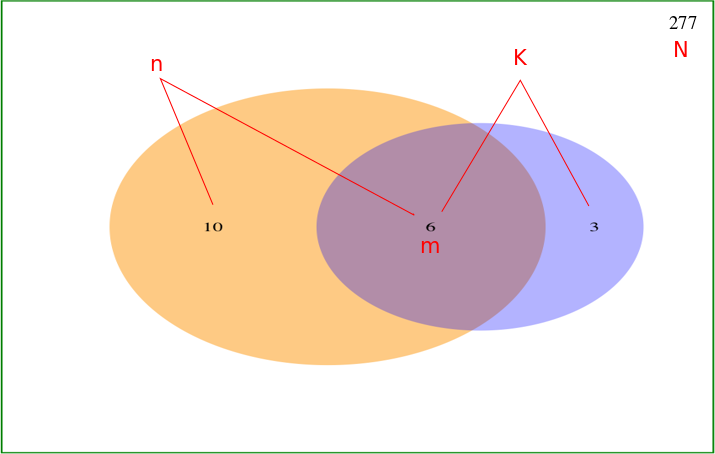

$$p=1-\sum_{k=0}^m \frac{\binom{K}{k}\binom{N-K}{n-k}}{\binom{N}{n}}$$
here $m$ is the number of shared miRNAs, $N$ is the total number of miRNAs in the database, $n$ is the number of miRNAs targeting the lncRNA, $K$ is the number of miRNAs targeting the protein coding gene.

### 4.3.2 Pearson correlation analysis

Pearson correlation coefficient is a measure of the strength of a linear association between two variables. As we all know, miRNAs are negative regulators of gene expression. If more common miRNAs are occupied by a lncRNA, less of them will bind to the target mRNA, thus increasing the expression level of mRNA. So expression of the lncRNA and mRNA in a ceRNA pair should be positively correlated.

### 4.3.3 Regulation pattern analysis

> Two methods are used to measure the regulatory role of miRNAs on the lncRNA and mRNA:
- Regulation similarity

We defined a measurement *regulation similarity score* to check the similarity between miRNAs-lncRNA expression correlation and miRNAs-mRNA expression correlation.

$$Regulation\ similarity\ score = 1-\frac{1}{M} \sum_{k=1}^M [{\frac{|corr(m_k,l)-corr(m_k,g)|}{|corr(m_k,l)|+|corr(m_k,g)|}}]^M$$

where $M$ is the total number of shared miRNAs, $k$ is the $k$th shared miRNAs, $corr(m_k, l)$ and $corr(m_k, g)$ represents the Pearson correlation between the $k$th miRNA and lncRNA, the $k$th miRNA and mRNA, respectively

- Sensitivity correlation

Sensitivity correlation is defined by Paci et al.(Paci, Colombo, and Farina 2014) to measure if the correlation between a lncRNA and mRNA is mediated by a miRNA in the lncRNA-miRNA-mRNA triplet. We take average of all triplets of a lncRNA-mRNA pair and their shared miRNAs as the sensitivity correlation between a selected lncRNA and mRNA.

$$Sensitivity\ correlation = corr(l,g)-\frac{1}{M}\sum_{k=1}^M {\frac{corr(l,g)-corr(m_k,l)corr(m_k,g)}{\sqrt{1-corr(m_k,l)^2}\sqrt{1-corr(m_k,g)^2}}}$$
where $M$ is the total number of shared miRNAs, $k$ is the $k$th shared miRNAs, $corr(l,g)$, $corr(m_k,l)$ and $corr(m_k, g)$ represents the Pearson correlation between the long non-coding RNA and the protein coding gene, the kth miRNA and lncRNA, the kth miRNA and mRNA, respectively

### 4.3.4 ceRNAs network analysis

The hypergeometric test of shared miRNAs, expression correlation analysis of lncRNA-mRNA pair, and regulation pattern analysis of shared miRNAs are all implemented in the `gdcCEAnalysis()` function.

#### 4.3.4.1 ceRNAs network analysis using internal databases

Users can use the internally incoporated databases of miRNA-mRNA (starBase v2.0, miRcode, and mirTarBase v7.0) and miRNA-lncRNA (starBase v2.0, miRcode, spongeScan) interactions to perform the ceRNAs network analysis.

```r
ceOutput <- gdcCEAnalysis(lnc         = rownames(deLNC),
                          pc          = rownames(dePC),
                          lnc.targets = 'starBase',
                          pc.targets  = 'starBase',
                          rna.expr    = rnaExpr,
                          mir.expr    = mirExpr)
```

#### 4.3.4.2 ceRNAs network analysis using user-provided datasets

`gdcCEAnalysis()` can also take user-provided miRNA-mRNA and miRNA-lncRNA interaction datasets, such as miRNA-target interactions predicted by [TargetScan](http://www.targetscan.org/vert_71/), miRanda, and [Diana Tools](http://diana.imis.athena-innovation.gr/DianaTools/index.php?r=site/index), etc. for the ceRNAs network analysis.

```r
### load miRNA-lncRNA interactions
data(lncTarget)

### load miRNA-mRNA interactions
data(pcTarget)
pcTarget[1:3]
```

```
## $ENSG00000138829
##  [1] "hsa-miR-200b-3p" "hsa-miR-429"     "hsa-miR-101-3p"
##  [4] "hsa-miR-137"     "hsa-miR-9-5p"    "hsa-miR-139-5p"
##  [7] "hsa-miR-200c-3p" "hsa-miR-136-5p"  "hsa-miR-494-3p"
## [10] "hsa-miR-495-3p"  "hsa-miR-154-5p"  "hsa-miR-410-3p"
## [13] "hsa-miR-211-5p"  "hsa-miR-140-5p"  "hsa-miR-22-3p"
## [16] "hsa-miR-33b-5p"  "hsa-miR-144-3p"  "hsa-miR-133a-3p"
## [19] "hsa-miR-23a-3p"  "hsa-miR-217"     "hsa-miR-33a-5p"
## [22] "hsa-miR-218-5p"  "hsa-miR-133b"    "hsa-miR-876-5p"
## [25] "hsa-miR-204-5p"  "hsa-miR-23b-3p"  "hsa-miR-23c"
##
## $ENSG00000113615
##  [1] "hsa-miR-200b-3p" "hsa-miR-200a-3p" "hsa-miR-429"
##  [4] "hsa-miR-30e-5p"  "hsa-miR-30c-5p"  "hsa-miR-92b-3p"
##  [7] "hsa-miR-199a-5p" "hsa-miR-181b-5p" "hsa-miR-181a-5p"
```

[output cut: 28 more lines]

```r
ceOutput <- gdcCEAnalysis(lnc         = rownames(deLNC),
                          pc          = rownames(dePC),
                          lnc.targets = lncTarget,
                          pc.targets  = pcTarget,
                          rna.expr    = rnaExpr,
                          mir.expr    = mirExpr)
```

### 4.3.5 Network visulization in Cytoscape

lncRNA-miRNA-mRNA interactions can be reported by the `gdcExportNetwork()` and visualized in **[Cytoscape](http://www.cytoscape.org/)**. `edges` should be imported as network and `nodes` should be imported as feature table.

```r
ceOutput2 <- ceOutput[ceOutput$hyperPValue<0.01 &
    ceOutput$corPValue<0.01 & ceOutput$regSim != 0,]

edges <- gdcExportNetwork(ceNetwork = ceOutput2, net = 'edges')
nodes <- gdcExportNetwork(ceNetwork = ceOutput2, net = 'nodes')

write.table(edges, file='edges.txt', sep='\t', quote=F)
write.table(nodes, file='nodes.txt', sep='\t', quote=F)
```

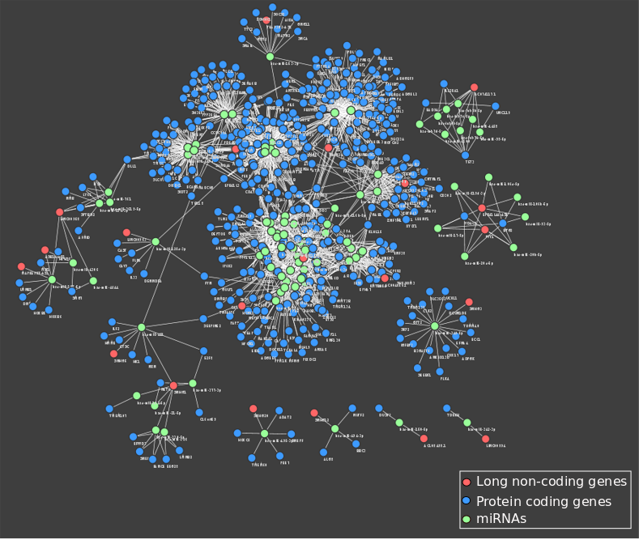

### 4.3.6 Correlation plot on a local webpage

`shinyCorPlot()` , a interactive plot function based on `shiny` package, can be easily operated by just clicking the genes in each drop down box (in the GUI window). By running `shinyCorPlot()` function, a local webpage would pop up and correlation plot between a lncRNA and mRNA would be automatically shown.

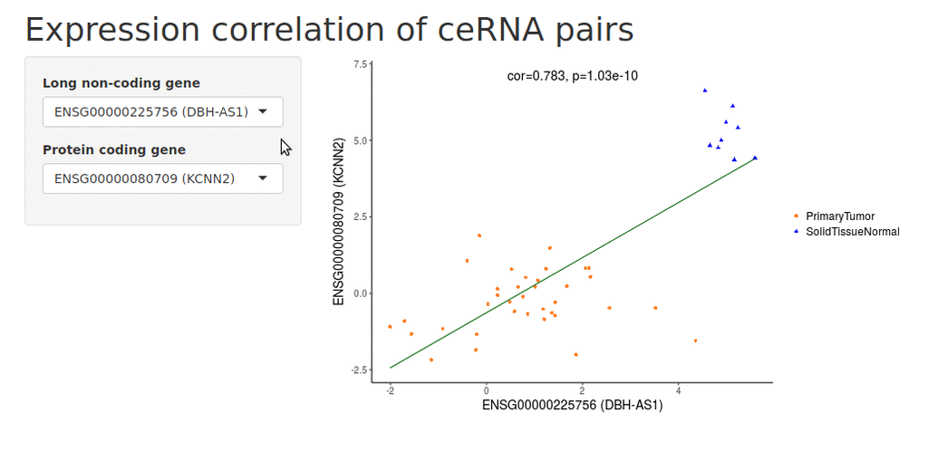

```r
shinyCorPlot(gene1    = rownames(deLNC),
             gene2    = rownames(dePC),
             rna.expr = rnaExpr,
             metadata = metaMatrix.RNA)
```

## 4.4 Other downstream analyses

Downstream analyses such as univariate survival analysis and functional enrichment analysis are developed in the `GDCRNATools` package to facilitate the identification of genes in the ceRNAs network that play important roles in prognosis or involve in important pathways.

### 4.4.1 Univariate survival analysis

Two methods are provided to perform univariate survival analysis: Cox Proportional-Hazards (CoxPH) model and Kaplan Meier (KM) analysis based on the [survival](https://cran.r-project.org/web/packages/survival/index.html) package. CoxPH model considers expression value as continous variable while KM analysis divides patients into high-expreesion and low-expression groups by a user-defined threshold such as median or mean. `gdcSurvivalAnalysis()` take a list of genes as input and report the hazard ratio, 95% confidence intervals, and test significance of each gene on overall survival.

#### 4.4.1.1 CoxPH analysis

```r
####### CoxPH analysis #######
survOutput <- gdcSurvivalAnalysis(gene     = rownames(deALL),
                                  method   = 'coxph',
                                  rna.expr = rnaExpr,
                                  metadata = metaMatrix.RNA)
```

#### 4.4.1.2 KM analysis

```r
####### KM analysis #######
survOutput <- gdcSurvivalAnalysis(gene     = rownames(deALL),
                                  method   = 'KM',
                                  rna.expr = rnaExpr,
                                  metadata = metaMatrix.RNA,
                                  sep      = 'median')
```

#### 4.4.1.3 KM plot on a local webpage by shinyKMPlot

The `shinyKMPlot()` function is also a simply `shiny` app which allow users view KM plots (based on the R package [survminer](https://cran.r-project.org/web/packages/survminer/index.html).) of all genes of interests on a local webpackage conveniently.

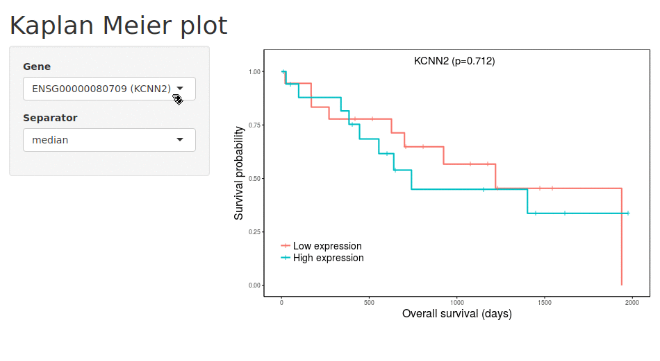

```r
shinyKMPlot(gene = rownames(deALL), rna.expr = rnaExpr,
            metadata = metaMatrix.RNA)
```

### 4.4.2 Functional enrichment analysis

`gdcEnrichAnalysis()` can perform Gene ontology (GO), Kyoto Encyclopedia of Genes and Genomes (KEGG) and Disease Ontology (DO) functional enrichment analyses of a list of genes simultaneously. GO and KEGG analyses are based on the R/Bioconductor packages [clusterProfilier](https://bioconductor.org/packages/release/bioc/html/clusterProfiler.html)(Yu et al. 2012) and [DOSE](https://bioconductor.org/packages/release/bioc/html/DOSE.html)(Yu et al. 2015). Redundant GO terms can be removed by specifying `simplify=TRUE` in the `gdcEnrichAnalysis()` function which uses the `simplify()` function in the [clusterProfilier](https://bioconductor.org/packages/release/bioc/html/clusterProfiler.html)(Yu et al. 2012) package.

```r
enrichOutput <- gdcEnrichAnalysis(gene = rownames(deALL), simplify = TRUE)
```

#### 4.4.2.1 Barplot

```r
data(enrichOutput)
```

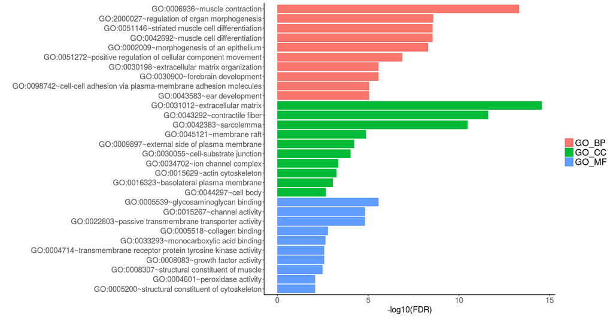

```r
gdcEnrichPlot(enrichOutput, type = 'bar', category = 'GO', num.terms = 10)
```

#### 4.4.2.2 Bubble plot

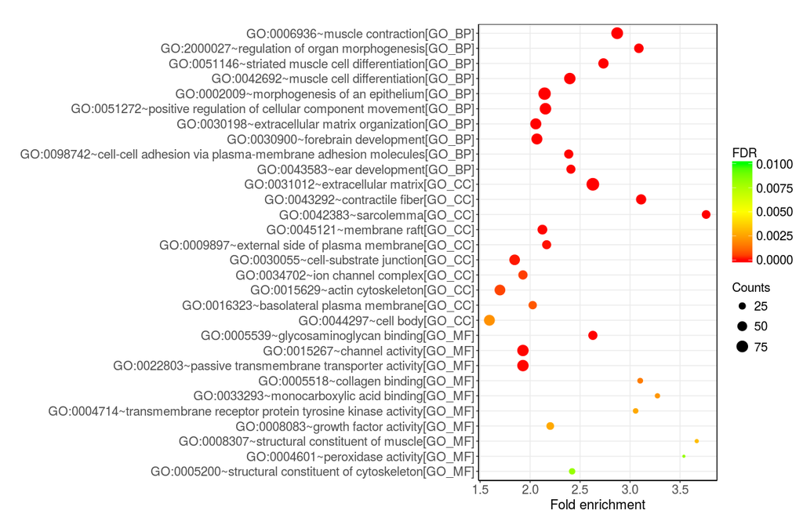

```r
gdcEnrichPlot(enrichOutput, type='bubble', category='GO', num.terms = 10)
```

#### 4.4.2.3 View pathway maps on a local webpage

`shinyPathview()` allows users view and download pathways of interests by simply selecting the pathway terms on a local webpage.

```r
library(pathview)

deg <- deALL$logFC
names(deg) <- rownames(deALL)
pathways <- as.character(enrichOutput$Terms[enrichOutput$Category=='KEGG'])
```

```r
shinyPathview(deg, pathways = pathways, directory = 'pathview')
```

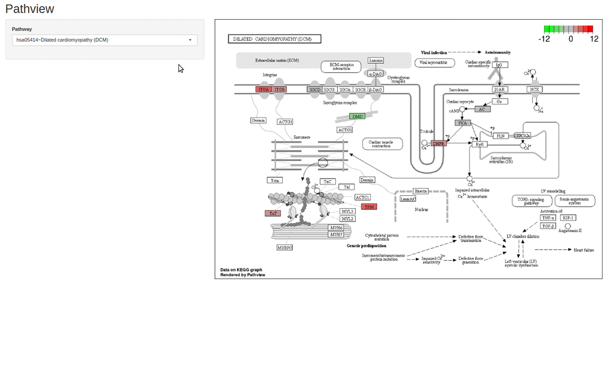

# References

Chou, Chih-Hung, Sirjana Shrestha, Chi-Dung Yang, Nai-Wen Chang, Yu-Ling Lin, Kuang-Wen Liao, Wei-Chi Huang, et al. 2017. “MiRTarBase Update 2018: A Resource for Experimentally Validated MicroRNA-Target Interactions.” *Nucleic Acids Research*, November, gkx1067–gkx1067. doi:10.1093/nar/gkx1067.

Colaprico, Antonio, Tiago C. Silva, Catharina Olsen, Luciano Garofano, Claudia Cava, Davide Garolini, Thais S. Sabedot, et al. 2016. “TCGAbiolinks: An R/Bioconductor Package for Integrative Analysis of TCGA Data.” *Nucleic Acids Research* 44 (8): e71. doi:10.1093/nar/gkv1507.

Furi’o-Tar’i, Pedro, Sonia Tarazona, Toni Gabald’on, Anton J. Enright, and Ana Conesa. 2016. “SpongeScan: A Web for Detecting MicroRNA Binding Elements in LncRNA Sequences.” *Nucleic Acids Research* 44 (Web Server issue): W176–W180. doi:10.1093/nar/gkw443.

Jeggari, Ashwini, Debora S Marks, and Erik Larsson. 2012. “MiRcode: A Map of Putative MicroRNA Target Sites in the Long Non-Coding Transcriptome.” *Bioinformatics* 28 (15): 2062–3. doi:10.1093/bioinformatics/bts344.

Langfelder, Peter, and Steve Horvath. 2008. “WGCNA: An R Package for Weighted Correlation Network Analysis.” *BMC Bioinformatics* 9 (December): 559. doi:10.1186/1471-2105-9-559.

Li, Jun-Hao, Shun Liu, Hui Zhou, Liang-Hu Qu, and Jian-Hua Yang. 2014. “StarBase V2.0: Decoding MiRNA-CeRNA, MiRNA-NcRNA and Protein–RNA Interaction Networks from Large-Scale CLIP-Seq Data.” *Nucleic Acids Research* 42 (Database issue): D92–D97. doi:10.1093/nar/gkt1248.

Love, Michael I., Wolfgang Huber, and Simon Anders. 2014. “Moderated Estimation of Fold Change and Dispersion for RNA-Seq Data with DESeq2.” *Genome Biology* 15 (December): 550. doi:10.1186/s13059-014-0550-8.

Paci, Paola, Teresa Colombo, and Lorenzo Farina. 2014. “Computational Analysis Identifies a Sponge Interaction Network Between Long Non-Coding RNAs and Messenger RNAs in Human Breast Cancer.” *BMC Systems Biology* 8 (July): 83. doi:10.1186/1752-0509-8-83.

Ritchie, Matthew E., Belinda Phipson, Di Wu, Yifang Hu, Charity W. Law, Wei Shi, and Gordon K. Smyth. 2015. “Limma Powers Differential Expression Analyses for RNA-Sequencing and Microarray Studies.” *Nucleic Acids Research* 43 (7): e47. doi:10.1093/nar/gkv007.

Robinson, Mark D., Davis J. McCarthy, and Gordon K. Smyth. 2010. “EdgeR: A Bioconductor Package for Differential Expression Analysis of Digital Gene Expression Data.” *Bioinformatics* 26 (1): 139–40. doi:10.1093/bioinformatics/btp616.

Yu, Guangchuang, Li-Gen Wang, Yanyan Han, and Qing-Yu He. 2012. “ClusterProfiler: An R Package for Comparing Biological Themes Among Gene Clusters.” *OMICS : A Journal of Integrative Biology* 16 (5): 284–87. doi:10.1089/omi.2011.0118.

Yu, Guangchuang, Li-Gen Wang, Guang-Rong Yan, and Qing-Yu He. 2015. “DOSE: An R/Bioconductor Package for Disease Ontology Semantic and Enrichment Analysis.” *Bioinformatics* 31 (4): 608–9. doi:10.1093/bioinformatics/btu684.

Zhu, Yitan, Peng Qiu, and Yuan Ji. 2014. “TCGA-Assembler: An Open-Source Pipeline for TCGA Data Downloading, Assembling, and Processing.” *Nature Methods* 11 (6): 599–600. doi:10.1038/nmeth.2956.